# Tutorial

### Latent Signal

Suppose the latent signal is provided by the function $$x_{true}(t_i) = \begin{cases} 0,\quad -N\leq t_i<-N/6 \\ 1,\quad -N/6 \leq t_i < N/6 \\ 0,\quad N/6 \leq t_i \leq N \end{cases}$$ where $x_{true}(t_i)$ is the intensity of each pixel $t_i$.

Define the domain to be equally spaced points in some interval

```python
def equispaced_points(number_of_points):
    """Returns an equally spaced array centered about zero
    with `number_of_points + 1` points."""
    return np.arange(
        -number_of_points // 2,
        number_of_points // 2 + 1,
        dtype=float)
```

Suppose the `number_of_points` is given to be $N$.

The $N+1$ *equispaced points* may be determined by the formula $t_i = t_{i-1} + 1$ where $t_1 = -\lceil N / 2 \rceil$.

Why do we choose equally spaced points? 🤔

### Constructing the Domain

```python
t = equispaced_points(number_of_points=512)  # returns `number_of_points + 1` points total
```

### Constructing the latent signal

```python
N = t.size
latent_signal = np.piecewise(
    t,
    [t < N/6, -N/6 <= t, N/6 <= t],
    [0, 1, 0])
```

We can construct this latent signal using the `numpy` function `piecewise`.

### The Latent Signal

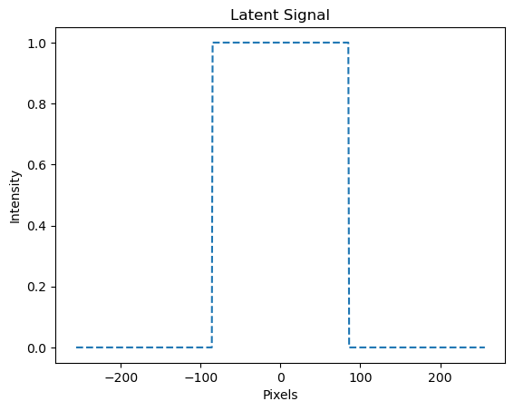

```python
plt.plot(t, latent_signal, '--')
plt.xlabel('Pixels')
plt.ylabel('Intensity')
plt.title('Latent Signal');
```

### Convolution

$$ (f*g)(t) = \int_{-\infty}^{\infty}f(\tau)g(t-\tau)\tau'$$

The kernel is assumed to be a mixture distribution

### Mixture Distribution

The mixture distribution $p$ is determined by weights and parameterized mixture components.

$$p(y)=\sum_{k=1}^nw_k p_k(\theta_k)$$

The distributions $p_k$ are the mixture components, $w_k$ denotes the mixture weights, and $\theta_k$ are the parameters for each component in the mixture. And $y=(w_1,\dots,w_n,\theta_1,\dots,\theta_n)$.

In our case let each mixture component be a normal distribution.

### Normal Distribution

```python
def normal_distribution(domain, standard_deviation):
    t = domain
    sigma = standard_deviation
    gaussian = np.exp(-0.5 * (t / sigma)**2)
    normalization_constant = 1/sum(gaussian)
    return gaussian * normalization_constant
```

### Derivatives

The derivative with respect to the standard deviation

```python
def derivative_wrt_standard_deviation(domain, standard_deviation):
    t = domain
    sigma = standard_deviation

    return normal_distribution(t, sigma) * (t**2) / (sigma**3)
    # return np.zeros_like(t)
```

### Parameters

First lets define the weights and the parameters of the mixture.

```python
true_weights = np.array([1.])  # mixture weights
true_standard_deviations = np.array([10])  # parameter
```

### Construct the mixture model

```python
true_mixture_model = Mixture(
    domain=t,
    mixture_weights=true_weights,
    mixture_component_parameters=true_standard_deviations,
    mixture_components=[normal_distribution, normal_distribution],
    mixture_component_derivatives=[derivative_wrt_standard_deviation])
```

### The Mixture Model

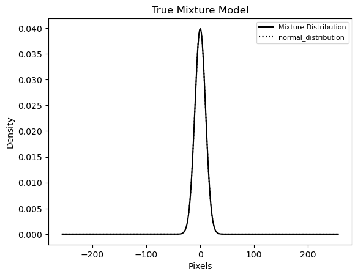

```python
true_mixture_model.visualize_mixture('True Mixture Model')
```

### Construct the blurring operator

```python
blur = BlurringOperator(true_mixture_model.array, toeplitz_structure)
```

#### Visualizing the Blurring Matrix

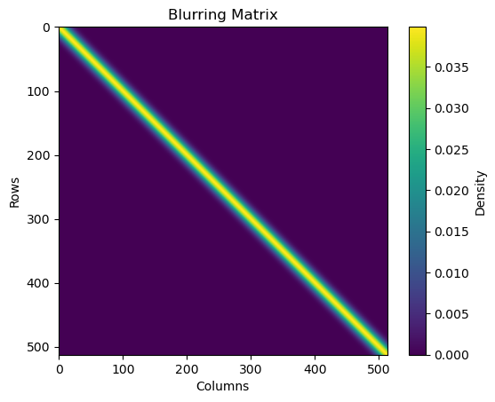

```python
plt.imshow(blur.matrix)
plt.colorbar(label='Density')
plt.ylabel('Rows')
plt.xlabel('Columns')
plt.title('Blurring Matrix');
```

### Noise

Lets say the data contains some percentage of gaussian noise

```python
def guassian_noise(percentage, latent_signal):
    np.random.seed(1) # Control randomness
    mu = 0 # Mean
    std = latent_signal.std() # Standard deviation
    N = latent_signal.size # number of points
    random_noise = np.random.normal(loc=mu, scale=std, size=N)
    return  random_noise * percentage
```

Setting the percentage of random noise in the data.

```python
percentage = 0.05
```

Creating the noise.

```python
noise = guassian_noise(percentage, latent_signal)
```

### Lets Plot the Noise

```python
def visualize(t, noise):
    fig = plt.figure()
    gs = fig.add_gridspec(1,2, width_ratios=(4, 1), left=0.1, right=0.9,
                      bottom=0.1, top=0.9, wspace=0.05, hspace=0.05)
    ax1 = fig.add_subplot(gs[0,0])
    ax1.grid(True)
    ax1.set_ylabel('Noise')
    ax1.set_xlabel('Per Pixel')

    ax2 = fig.add_subplot(gs[0, 1], sharey=ax1)
    ax2.tick_params(axis="y", labelleft=False)
    ax2.set_xlabel('Count')

    ax1.plot(t, noise)
    ax2.hist(noise, 40, density=True, orientation='horizontal')
```

### The Noise

```
Standard Deviation:  0.023184848121319747
Mean:  0.00116871125398896
latent signal std:  0.023570226039551587
```

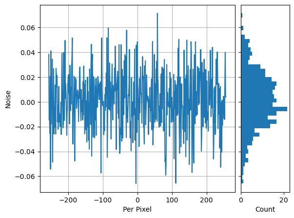

```python
visualize(t, noise)
print('Standard Deviation: ', noise.std())
print('Mean: ', noise.mean())
print('latent signal std: ', latent_signal.std() * percentage)
```

### The Data

```python
data = blur @ latent_signal + noise
```

### Visualizing the Data

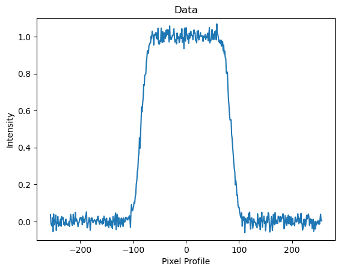

```python
plt.plot(t, data)
plt.title('Data')
plt.xlabel('Pixel Profile')
plt.ylabel('Intensity')
plt.ylim([-0.1, 1.1]);
```

## Deconvolution

Aim is to solve the optimization problem

$$\min_{x,y}\{\|K(y) x - d\|_2^2 + \lambda^2 \|L x\|^2_2 \}$$

where

$K(y)\in\mathbb{R}^{m\times m}$: blurring matrix,

$y\in\mathbb{R}^{k}$: parameters for kernel of convolution,

$x\in\mathbb{R}^{m}$: signal,

$d\in\mathbb{R}^m$: data containing convoluted latent signal plus additive noise,

$\lambda>0$: regularization parameter,

$L\in\mathbb{R}^{m\times m}$: regularization matrix.

### Initial Mixture Mixture

```python
initial_standard_deviations = np.array([20, 45, 60])
initial_weights = np.array([0.33, 0.33, 0.33])
```

```python
initial_mixture_model = Mixture(
    domain=t,
    mixture_weights=initial_weights,
    mixture_component_parameters=initial_standard_deviations,
    mixture_components=[normal_distribution for _ in range(3)],
    mixture_component_derivatives=[
        derivative_wrt_standard_deviation])
```

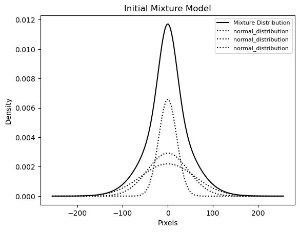

```python
initial_mixture_model.visualize_mixture('Initial Mixture Model')
```

### Regularization Matrix

```python
def total_variation(x):
    BETA = 1e-16
    ones = np.ones_like(x)
    D = spdiags([-ones, ones], diags=[0, 1]) # forward difference
    return np.diag(1/(((D*x)**2 + BETA**2)**(1/4))) @ D
```

### Jacobian

```python
def rjf_jacobian(signal, partial_derivatives, structure):
    result = []
    for derivative in partial_derivatives:
        matrix = structure(derivative, derivative.size // 2)
        result.append(matrix @ signal)
    return np.array(result).T
```

### Variable Projection Method

```python
mixture_model, result, iteration = variable_projection(
    data,
    initial_signal=latent_signal,
    initial_mixture_model=initial_mixture_model,
    blur_structure=partial(toeplitz_structure),
    jacobian=rjf_jacobian,
    regularization_parameter=1e-2,
    regularization_matrix=total_variation,
    max_iterations=160)
```

### The Mixture Model

```python
def visualize_error(true, estimated, xlabel, ylabel, title):
    error = estimated - true

    fig = plt.figure()
    gs = fig.add_gridspec(2,1, height_ratios=(4, 1), left=0.1, right=0.9,
                      bottom=0.1, top=0.9, wspace=0.05, hspace=0.05)
    ax1 = fig.add_subplot(gs[0,0])
    ax1.set_ylabel(ylabel)
    ax1.tick_params(axis="x", bottom=False)

    ax2 = fig.add_subplot(gs[1, 0], sharex=ax1)
    ax2.set_ylabel('Error')
    ax2.set_xlabel(xlabel)

    ax1.plot(t, true, 'k--', label='True')
    ax1.plot(t, estimated, alpha=0.5, label='Estimated')
    ax2.plot(t, error)

    ax1.set_title(title)
    ax1.legend();
```

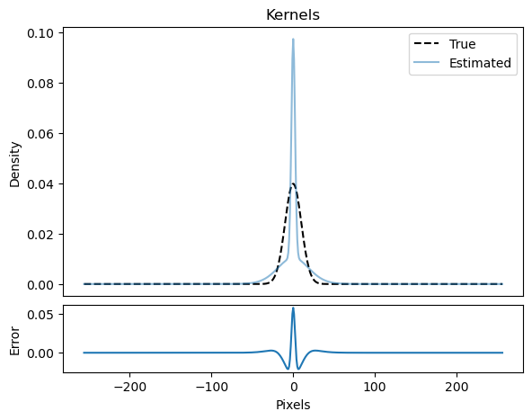

```python
visualize_error(true_mixture_model.array, mixture_model.array, 'Pixels', 'Density', 'Kernels')
```

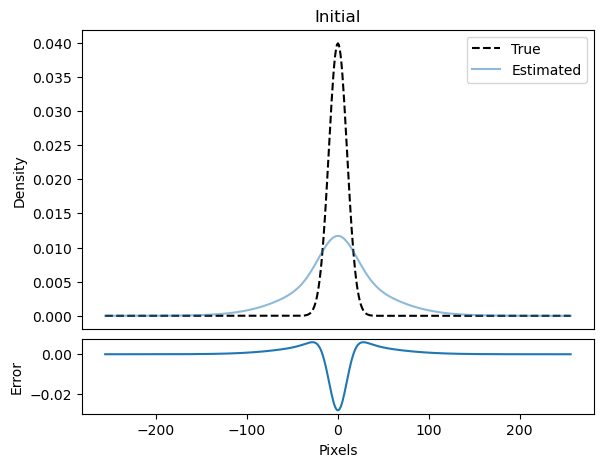

```python
visualize_error(true_mixture_model.array, initial_mixture_model.array, 'Pixels', 'Density', 'Initial')
```

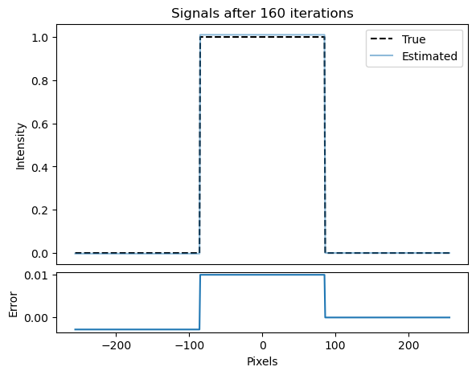

```python
visualize_error(latent_signal, result, 'Pixels', 'Intensity', f'Signals after {iteration} iterations')
```

```python
K = BlurringOperator(mixture_model.array, toeplitz_structure)
error_estimate = K @ result - data
```

```
Mean:  0.0012550537415694383
STD:  0.037873371136959245
```

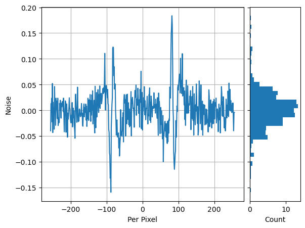

```python
visualize(t, error_estimate)
print('Mean: ', error_estimate.mean())
print('STD: ', error_estimate.std())
```

```
Mean:  0.00116871125398896
STD:  0.023184848121319747
```

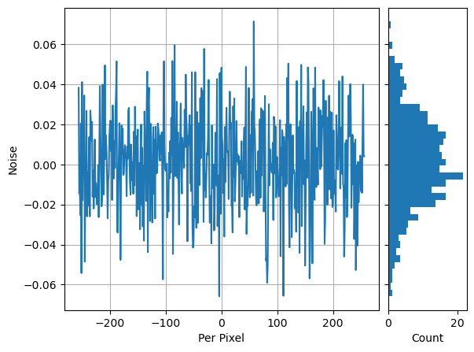

```python
visualize(t, noise)
print('Mean: ', noise.mean())
print('STD: ', noise.std())
```

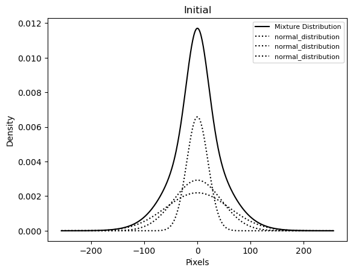

```python
initial_mixture_model.visualize_mixture('Initial')
```

```python
print('Initial Parameters: ', initial_mixture_model.parameters)
print('Initial Weights: ', initial_mixture_model.weights)
print('Result Parameters: ', mixture_model.parameters)
print('Result Weighths: ', mixture_model.weights)
```

```
Initial Parameters:  [20 45 60]
Initial Weights:  [0.33 0.33 0.33]
Result Parameters:  [-22.73452392   2.26547608  17.26547608]
Result Weighths:  [0.22792959 0.49429521 0.2777752 ]
```